# Lab2

## Lab 2 More data frames

### 1 Load data

```python
# imprt the packages
import pandas as pd
import matplotlib.pyplot as plt
```

```python
# 1.1 Load the dataset in the wrong way
df_wrong = pd.read_csv('king-house-prices.csv')
df_wrong
```

|  | id\tdate\tprice\tbedrooms\tbathrooms\tsqft_living\tsqft_lot\tfloors\twaterfront\tview\tcondition\tgrade\tsqft_above\tsqft_basement\tyr_built\tyr_renovated\tzipcode\tlat\tlong\tsqft_living15\tsqft_lot1… |
| --- | --- |
| 0 | 7129300520\t2014-10-13\t221900\t3\t1\t1180\t56... |
| 1 | 6414100192\t2014-12-09\t538000\t3\t2.25\t2570\... |
| 2 | 5631500400\t2015-02-25\t180000\t2\t1\t770\t100... |
| 3 | 2487200875\t2014-12-09\t604000\t4\t3\t1960\t50... |
| 4 | 1954400510\t2015-02-18\t510000\t3\t2\t1680\t80... |
| ... | ... |
| 21608 | 263000018\t2014-05-21\t360000\t3\t2.5\t1530\t1... |
| 21609 | 6600060120\t2015-02-23\t4e+05\t4\t2.5\t2310\t5... |
| 21610 | 1523300141\t2014-06-23\t402101\t2\t0.75\t1020\... |
| 21611 | 291310100\t2015-01-16\t4e+05\t3\t2.5\t1600\t23... |
| 21612 | 1523300157\t2014-10-15\t325000\t2\t0.75\t1020\... |

21613 rows × 1 columns

```python
# Check how many rows and columns do we have
df_wrong.shape
```

```
(21613, 1)
```

For the wrong dataset that use the default separator (comma), there are 21613 rows and 1 columns.

```python
# 1.2 Print a few random lines of data
df_wrong.sample(5)
```

|  | id\tdate\tprice\tbedrooms\tbathrooms\tsqft_living\tsqft_lot\tfloors\twaterfront\tview\tcondition\tgrade\tsqft_above\tsqft_basement\tyr_built\tyr_renovated\tzipcode\tlat\tlong\tsqft_living15\tsqft_lot1… |
| --- | --- |
| 13950 | 5015000596\t2014-12-01\t834000\t3\t2.25\t2550\... |
| 8112 | 255550230\t2014-11-18\t299950\t3\t2.5\t1570\t2... |
| 1955 | 3904921070\t2014-08-12\t590000\t4\t2.5\t2340\t... |
| 4042 | 7980900011\t2015-04-27\t412450\t3\t2\t1910\t13... |
| 9860 | 1081300390\t2014-10-30\t330000\t3\t1.75\t2020\... |

```python
# 1.3 Load the dataset in the correct way
df_correct = pd.read_csv('king-house-prices.csv', sep='\t')
df_correct
```

|  | id | date | price | bedrooms | bathrooms | sqft_living | sqft_lot | floors | waterfront | view | ... | grade | sqft_above | sqft_basement | yr_built | yr_renovated | zipcode | lat | long | sqft_living15 | sqft_lot15 |
| --- | --- | --- | --- | --- | --- | --- | --- | --- | --- | --- | --- | --- | --- | --- | --- | --- | --- | --- | --- | --- | --- |
| 0 | 7129300520 | 2014-10-13 | 221900.0 | 3 | 1.00 | 1180 | 5650 | 1.0 | False | 0 | ... | 7 | 1180 | 0 | 1955 | 0 | 98178 | 47.5112 | -122.257 | 1340 | 5650 |
| 1 | 6414100192 | 2014-12-09 | 538000.0 | 3 | 2.25 | 2570 | 7242 | 2.0 | False | 0 | ... | 7 | 2170 | 400 | 1951 | 1991 | 98125 | 47.7210 | -122.319 | 1690 | 7639 |
| 2 | 5631500400 | 2015-02-25 | 180000.0 | 2 | 1.00 | 770 | 10000 | 1.0 | False | 0 | ... | 6 | 770 | 0 | 1933 | 0 | 98028 | 47.7379 | -122.233 | 2720 | 8062 |
| 3 | 2487200875 | 2014-12-09 | 604000.0 | 4 | 3.00 | 1960 | 5000 | 1.0 | False | 0 | ... | 7 | 1050 | 910 | 1965 | 0 | 98136 | 47.5208 | -122.393 | 1360 | 5000 |
| 4 | 1954400510 | 2015-02-18 | 510000.0 | 3 | 2.00 | 1680 | 8080 | 1.0 | False | 0 | ... | 8 | 1680 | 0 | 1987 | 0 | 98074 | 47.6168 | -122.045 | 1800 | 7503 |
| ... | ... | ... | ... | ... | ... | ... | ... | ... | ... | ... | ... | ... | ... | ... | ... | ... | ... | ... | ... | ... | ... |
| 21608 | 263000018 | 2014-05-21 | 360000.0 | 3 | 2.50 | 1530 | 1131 | 3.0 | False | 0 | ... | 8 | 1530 | 0 | 2009 | 0 | 98103 | 47.6993 | -122.346 | 1530 | 1509 |
| 21609 | 6600060120 | 2015-02-23 | 400000.0 | 4 | 2.50 | 2310 | 5813 | 2.0 | False | 0 | ... | 8 | 2310 | 0 | 2014 | 0 | 98146 | 47.5107 | -122.362 | 1830 | 7200 |
| 21610 | 1523300141 | 2014-06-23 | 402101.0 | 2 | 0.75 | 1020 | 1350 | 2.0 | False | 0 | ... | 7 | 1020 | 0 | 2009 | 0 | 98144 | 47.5944 | -122.299 | 1020 | 2007 |
| 21611 | 291310100 | 2015-01-16 | 400000.0 | 3 | 2.50 | 1600 | 2388 | 2.0 | False | 0 | ... | 8 | 1600 | 0 | 2004 | 0 | 98027 | 47.5345 | -122.069 | 1410 | 1287 |
| 21612 | 1523300157 | 2014-10-15 | 325000.0 | 2 | 0.75 | 1020 | 1076 | 2.0 | False | 0 | ... | 7 | 1020 | 0 | 2008 | 0 | 98144 | 47.5941 | -122.299 | 1020 | 1357 |

21613 rows × 21 columns

```python
# Check how many rows and columns do we have now
df_correct.shape
```

```
(21613, 21)
```

For the correct dataset that load it correctly–use tab as separator, there are 21613 rows and 21 columns.

```python
# 1.4 Print a few random lines of data
df_correct.sample(5)
```

|  | id | date | price | bedrooms | bathrooms | sqft_living | sqft_lot | floors | waterfront | view | ... | grade | sqft_above | sqft_basement | yr_built | yr_renovated | zipcode | lat | long | sqft_living15 | sqft_lot15 |
| --- | --- | --- | --- | --- | --- | --- | --- | --- | --- | --- | --- | --- | --- | --- | --- | --- | --- | --- | --- | --- | --- |
| 7978 | 4310700665 | 2015-03-05 | 450000.0 | 4 | 3.00 | 2200 | 4466 | 2.0 | False | 0 | ... | 7 | 2200 | 0 | 1968 | 0 | 98103 | 47.7005 | -122.339 | 1780 | 2250 |
| 13675 | 4389201075 | 2014-07-31 | 1900000.0 | 4 | 2.50 | 3680 | 13351 | 2.0 | False | 2 | ... | 9 | 3680 | 0 | 1946 | 1982 | 98004 | 47.6154 | -122.214 | 3410 | 11700 |
| 20820 | 2767604212 | 2014-10-29 | 452000.0 | 2 | 2.50 | 1260 | 1131 | 3.0 | False | 0 | ... | 8 | 1260 | 0 | 2006 | 0 | 98107 | 47.6715 | -122.384 | 1490 | 2500 |
| 17237 | 9276200190 | 2015-04-16 | 569950.0 | 5 | 1.00 | 1420 | 6250 | 1.5 | False | 0 | ... | 8 | 1420 | 0 | 1926 | 0 | 98116 | 47.5807 | -122.389 | 1420 | 6250 |
| 13559 | 3375300360 | 2014-07-01 | 217500.0 | 3 | 1.75 | 1400 | 9546 | 1.0 | False | 0 | ... | 7 | 1400 | 0 | 1984 | 0 | 98003 | 47.3179 | -122.331 | 1660 | 8550 |

5 rows × 21 columns

#### 1.5

When the dataset is loaded with the incorrect separator, the output will contain less columns than anticipated, and the data will appear disorganized. In contrast, when the dataset is loaded with the correct separator, the output will display the correct number of columns, and the data will appear well-organized.

```python
# 1.6 Make a subset that contains date, price, condition, lat, long and waterfront.
df_subset = df_correct[['date', 'price', 'condition', 'lat', 'long', 'waterfront']]
df_subset
```

|  | date | price | condition | lat | long | waterfront |
| --- | --- | --- | --- | --- | --- | --- |
| 0 | 2014-10-13 | 221900.0 | 3 | 47.5112 | -122.257 | False |
| 1 | 2014-12-09 | 538000.0 | 3 | 47.7210 | -122.319 | False |
| 2 | 2015-02-25 | 180000.0 | 3 | 47.7379 | -122.233 | False |
| 3 | 2014-12-09 | 604000.0 | 5 | 47.5208 | -122.393 | False |
| 4 | 2015-02-18 | 510000.0 | 3 | 47.6168 | -122.045 | False |
| ... | ... | ... | ... | ... | ... | ... |
| 21608 | 2014-05-21 | 360000.0 | 3 | 47.6993 | -122.346 | False |
| 21609 | 2015-02-23 | 400000.0 | 3 | 47.5107 | -122.362 | False |
| 21610 | 2014-06-23 | 402101.0 | 3 | 47.5944 | -122.299 | False |
| 21611 | 2015-01-16 | 400000.0 | 3 | 47.5345 | -122.069 | False |
| 21612 | 2014-10-15 | 325000.0 | 3 | 47.5941 | -122.299 | False |

21613 rows × 6 columns

### 2 Listing price

```python
# 2.1 Compute the average listing price
df_subset['price'].mean()
```

```
540088.1417665294
```

The average listing price is 540088.1418.

```python
# 2.2 Compute the average price in each of the “condition” category
df_subset.groupby('condition')['price'].mean()
```

```
condition
1    334431.666667
2    327287.145349
3    542012.578148
4    521200.390033
5    612418.089359
Name: price, dtype: float64
```

```python
# 2.3 Print three most expensive listings
sorted_price = df_subset.sort_values('price', ascending=False)
sorted_price.head(3)
```

|  | date | price | condition | lat | long | waterfront |
| --- | --- | --- | --- | --- | --- | --- |
| 7252 | 2014-10-13 | 7700000.0 | 4 | 47.6298 | -122.323 | False |
| 3914 | 2014-06-11 | 7062500.0 | 3 | 47.6500 | -122.214 | True |
| 9254 | 2014-09-19 | 6885000.0 | 3 | 47.6305 | -122.240 | False |

```python
# Print three most cheapest listings
sorted_price.tail(3)
```

|  | date | price | condition | lat | long | waterfront |
| --- | --- | --- | --- | --- | --- | --- |
| 465 | 2014-05-23 | 80000.0 | 2 | 47.6499 | -121.909 | False |
| 15293 | 2014-05-06 | 78000.0 | 1 | 47.4739 | -122.280 | False |
| 1149 | 2015-02-17 | 75000.0 | 3 | 47.2638 | -121.906 | False |

```python
# 2.4 Create a single data frame that contains both 3 cheapest and 3 most expensive listings
sorted_price_df = pd.concat([sorted_price.head(3), sorted_price.tail(3)]).sort_values('price')
sorted_price_df
```

|  | date | price | condition | lat | long | waterfront |
| --- | --- | --- | --- | --- | --- | --- |
| 1149 | 2015-02-17 | 75000.0 | 3 | 47.2638 | -121.906 | False |
| 15293 | 2014-05-06 | 78000.0 | 1 | 47.4739 | -122.280 | False |
| 465 | 2014-05-23 | 80000.0 | 2 | 47.6499 | -121.909 | False |
| 9254 | 2014-09-19 | 6885000.0 | 3 | 47.6305 | -122.240 | False |
| 3914 | 2014-06-11 | 7062500.0 | 3 | 47.6500 | -122.214 | True |
| 7252 | 2014-10-13 | 7700000.0 | 4 | 47.6298 | -122.323 | False |

```python
# 2.5 Extract the most expensive listing for each “condition” category
cheapest_by_condition = df_subset.loc[df_subset.groupby('condition')['price'].idxmin()]
cheapest_by_condition
```

|  | date | price | condition | lat | long | waterfront |
| --- | --- | --- | --- | --- | --- | --- |
| 15293 | 2014-05-06 | 78000.0 | 1 | 47.4739 | -122.280 | False |
| 465 | 2014-05-23 | 80000.0 | 2 | 47.6499 | -121.909 | False |
| 1149 | 2015-02-17 | 75000.0 | 3 | 47.2638 | -121.906 | False |
| 5866 | 2014-10-14 | 89000.0 | 4 | 47.3026 | -122.363 | False |
| 17197 | 2014-05-12 | 110000.0 | 5 | 47.4235 | -122.051 | False |

```python
# Extract the cheapest listing for each “condition” category
expensive_by_condition = df_subset.loc[df_subset.groupby('condition')['price'].idxmax()]
expensive_by_condition
```

|  | date | price | condition | lat | long | waterfront |
| --- | --- | --- | --- | --- | --- | --- |
| 18876 | 2015-02-11 | 1500000.0 | 1 | 47.6453 | -122.214 | False |
| 11225 | 2014-05-13 | 2555000.0 | 2 | 47.6610 | -122.269 | True |
| 3914 | 2014-06-11 | 7062500.0 | 3 | 47.6500 | -122.214 | True |
| 7252 | 2014-10-13 | 7700000.0 | 4 | 47.6298 | -122.323 | False |
| 6508 | 2015-04-21 | 3650000.0 | 5 | 47.6515 | -122.277 | True |

### 3 Proportions

```python
# 3.1 Percentage of listings cheaper than $200,000
(df_subset['price'] < 200000).mean() * 100
```

```
3.6367001341785032
```

There are 3.6367% of listing are cheaper than $200k.

```python
# Percentage of listings are over $1M
(df_subset['price'] > 1000000).mean() * 100
```

```
6.778327858233471
```

There are 6.7783% of listings are over $1M.

```python
# 3.2 Percentage of listings less than $1M and overlooking waterfront
((df_subset['price'] < 1000000) & (df_subset['waterfront'] == 1)).mean() * 100
```

```
0.26835700735668344
```

The percentage of listings cost less than $1M and are overlooking waterfront is 0.268357%.

### 4 Plotting

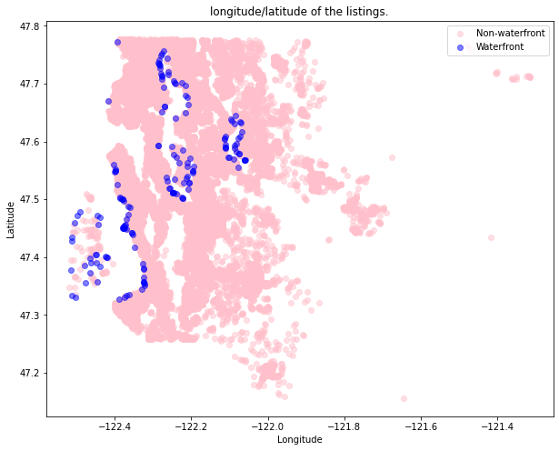

```python
# 4.1 Create a scatter plot of longitude and latitude, colored by waterfront
fig, ax = plt.subplots(figsize=(10,8))
ax.scatter(df_subset.loc[df_subset['waterfront'] == 0, 'long'], df_subset.loc[df_subset['waterfront'] == 0, 'lat'], color='pink', alpha=0.5, label='Non-waterfront')
ax.scatter(df_subset.loc[df_subset['waterfront'] == 1, 'long'], df_subset.loc[df_subset['waterfront'] == 1, 'lat'], color='blue', alpha=0.5, label='Waterfront')
ax.set_xlabel('Longitude')
ax.set_ylabel('Latitude')
ax.set_title('longitude/latitude of the listings.')
ax.legend(loc='upper right')
plt.show()
```

#### 4.2

As seen on the map, it shows the shape of Seattle.The waterfront properties are near lakes and sea shore.This makes logic, as waterfront properties are typically more desirable and thus cost more. The non-waterfront properties are more equitably distributed across the region.